# Course Project

Zhuozhuo Tu

March 5, 2017

# My app

The goal of my app is to predict iris species. The appearance of my app is given in the figure below. It consists of two panels. The left panel is where you control the input, and the right panel shows our prediction results. There are three tabs in the right panel. Help tab tells you how to use my app. Data tab shows the training set for our prediction algorithm. Our Prediction tab gives predicted iris species.

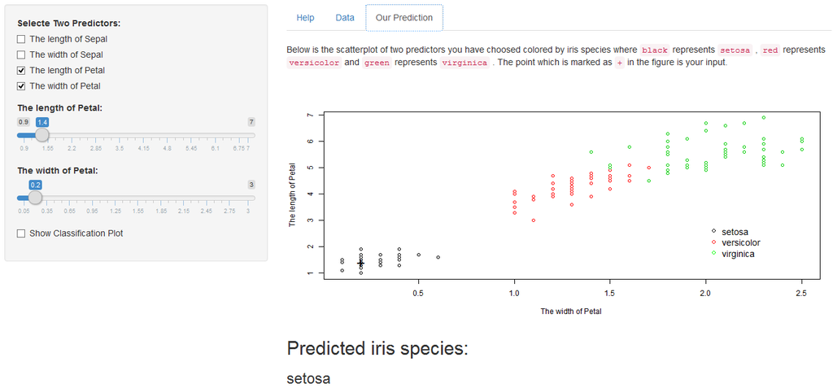

# Input

There are four features: Sepal.Length, Sepal.Width, Patal.Length and Patal.Width which are the indictors of iris species in our training set. Before running this app, select two predictors from the four features and then assign values for the two predictors you choose by moving the handle in the slider. Our training set is shown as follows:

```r
head(iris)
```

```
##   Sepal.Length Sepal.Width Petal.Length Petal.Width Species
## 1          5.1         3.5          1.4         0.2  setosa
## 2          4.9         3.0          1.4         0.2  setosa
## 3          4.7         3.2          1.3         0.2  setosa
## 4          4.6         3.1          1.5         0.2  setosa
## 5          5.0         3.6          1.4         0.2  setosa
## 6          5.4         3.9          1.7         0.4  setosa
```

# Algorithm

Our prediction is based on the support vector machine algorithm. To understand how it works, a SVM classification plot is given when Patal.Width and Patal. Length are selected as predictors. As we can see from the figure, there are three areas colored by iris species. When your input sits in some area the algorithms will output the iris species which corresponds to this area.

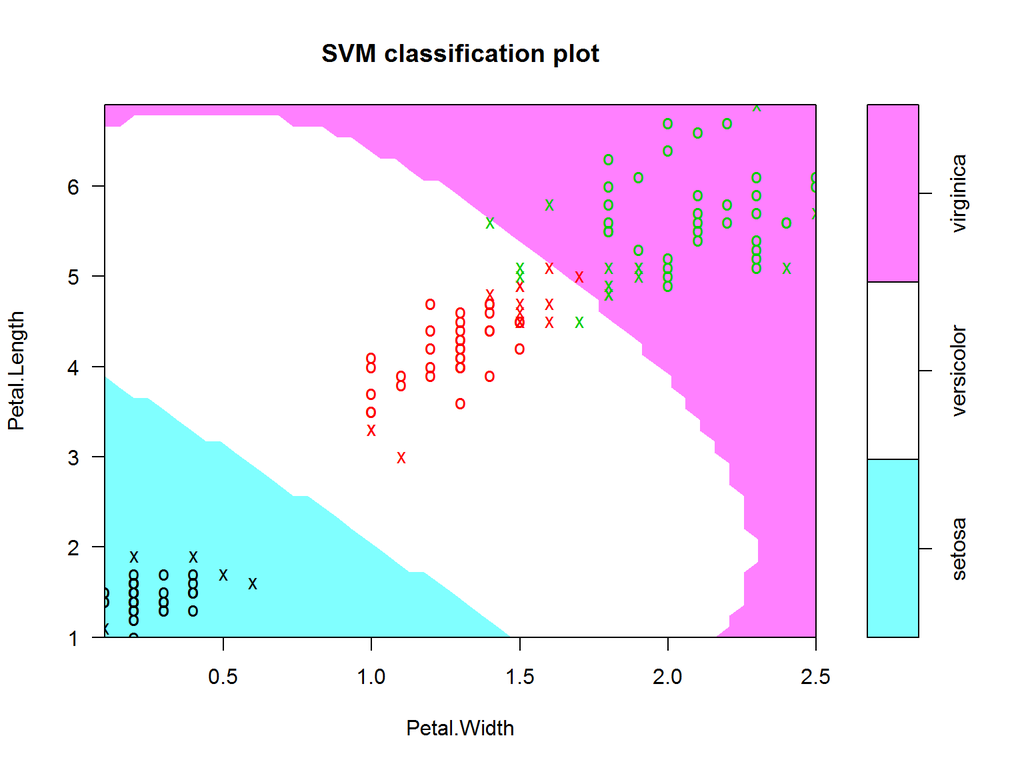

```r
library(e1071)
sv<-svm(Species~Petal.Length+Petal.Width,data=iris,cross=5)
plot(sv,iris[,c(3,4,5)])
```

# Prediction

Our Prediction tab in the right panel shows the scatterplot of two predictors you have choosed colored by iris species and the predicted iris species for your input. Supposing that you have selected Patal.Width and Patal. Length as predictors and want to predict the iris species when Petal. Length=4.6 and Petal.Width=1.6, the prediction is shown as follows. The + mark in the figure is our input and the predicted iris species is given as versicolor.

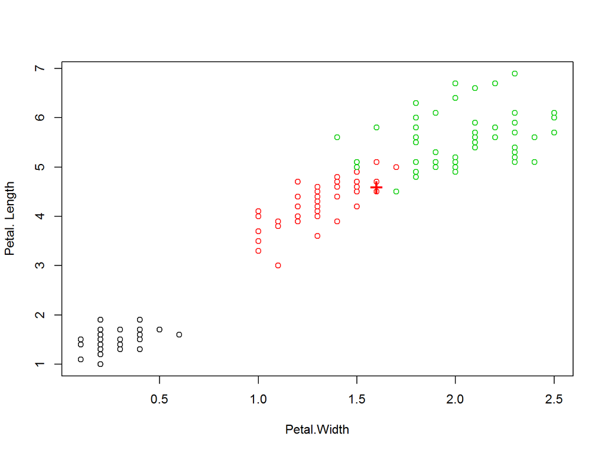

```
##          1
## versicolor
## Levels: setosa versicolor virginica
```